# tradeoff_mod Demo

29 January 2015

## Overview

This simulations runs throughs 54 permutations of these combinations using the model's batch mode function, `tradeoff_batch`.

## Model Inputs

Productivity of 9 key crops (t/ha)

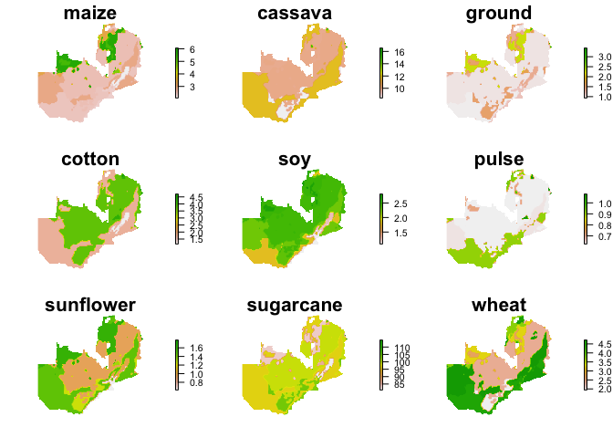

Maize and Soy Potential Yields (t/ha)

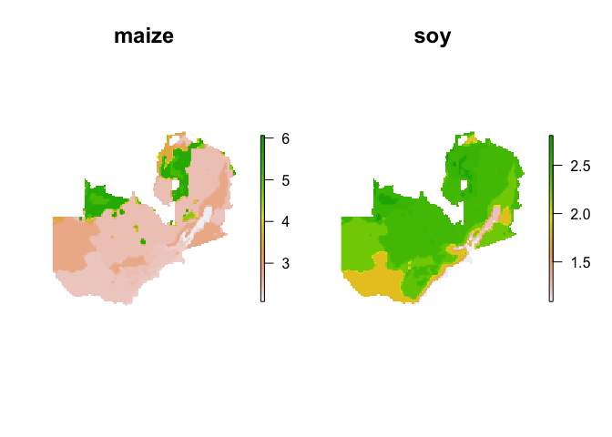

Biodiversity Protection Priorities (lower is more important)

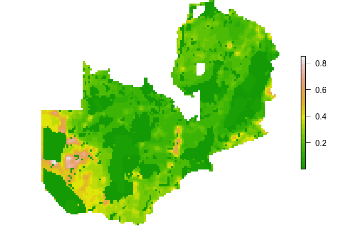

Vegetative + Soil Carbon (t/ha)

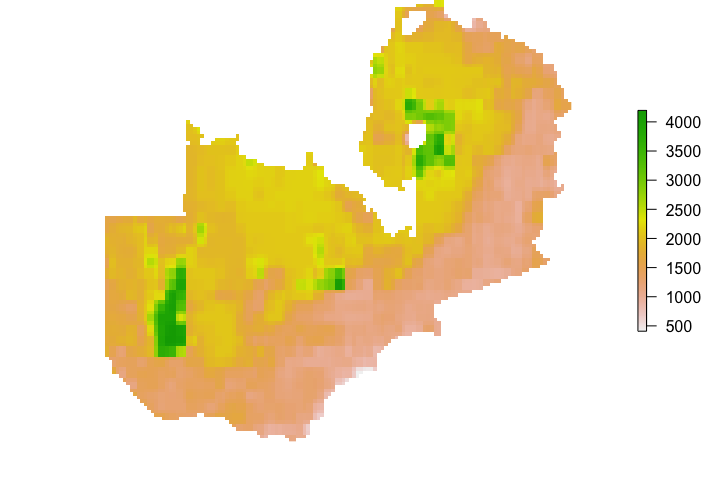

Potential Carbon Loss to Yield Ratio (t/ha, lower is better)

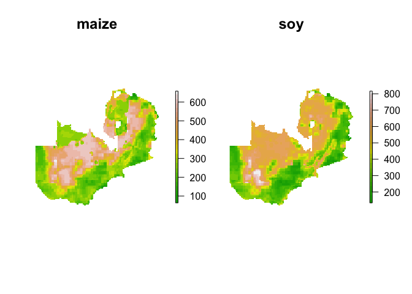

Yield X Carbon Constraint (highest is first to convert)

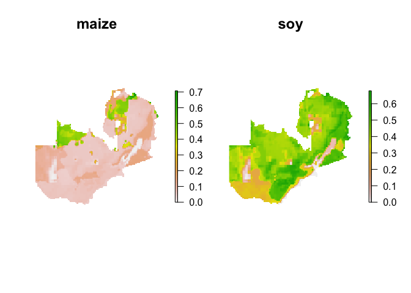

Inputs: Transport Costs

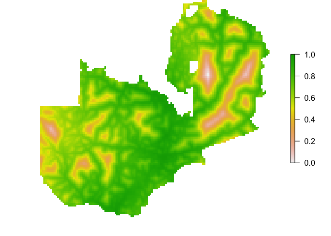

## Results

## The Impact of The Four Constraints

- These examples will be from the intermediate case that:
  - Assumes a tripling of demand for all 9 crops
  - No modification of yield potential
- The `targets*` function of the tradeoff_mod library specifies:
  - The productions targets (in tonnes) that need to met
  - What percent of those can be met on existing cropland
  - What percent will have to come from new cropland

Crop Production Targets

|  | current | potential | target | %existing | %newland |
| --- | --- | --- | --- | --- | --- |
| maize | 751244 | 665390 | 2253732 | 29.5 | 70.5 |
| cassava | 643479 | 924464 | 1930437 | 47.9 | 52.1 |
| ground | 43737 | 93705 | 131211 | 71.4 | 28.6 |
| cotton | 63099 | 89362 | 189297 | 47.2 | 52.8 |
| soy | 15301 | 11465 | 45903 | 25.0 | 75.0 |
| pulse | 14436 | 6138 | 43308 | 14.2 | 85.8 |
| sunflower | 8213 | 11793 | 24639 | 47.9 | 52.1 |
| sugarcane | 1695805 | 7183 | 5087415 | 0.1 | 99.9 |
| wheat | 64757 | 3553 | 194271 | 1.8 | 98.2 |

Constraint: Yield

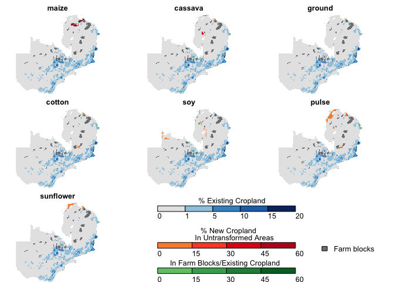

Constraint: Carbon

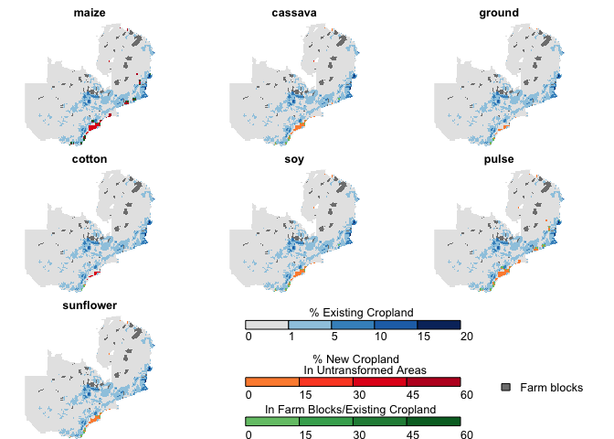

Constraint: Biodiversity

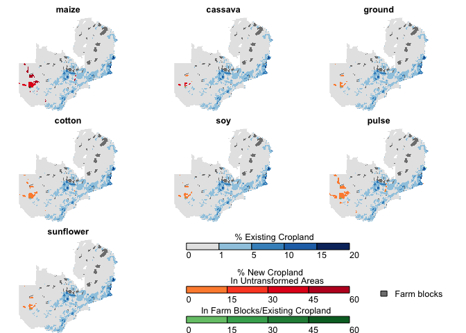

Constraint: Transport Cost

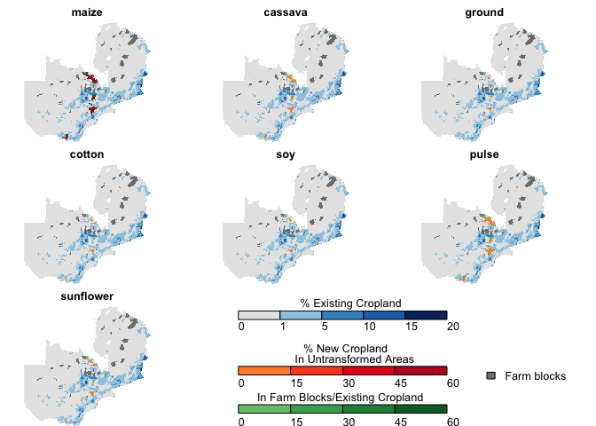

Constraints: Yield & Carbon

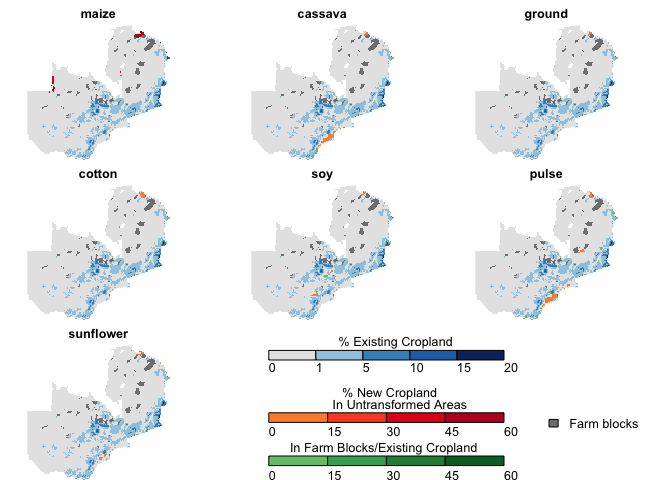

Constraints: Yield & Biodiversity

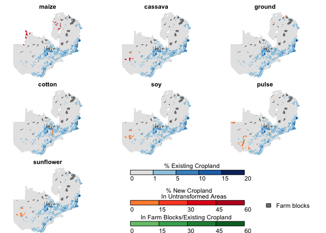

Constraints: Yield & Transport Cost

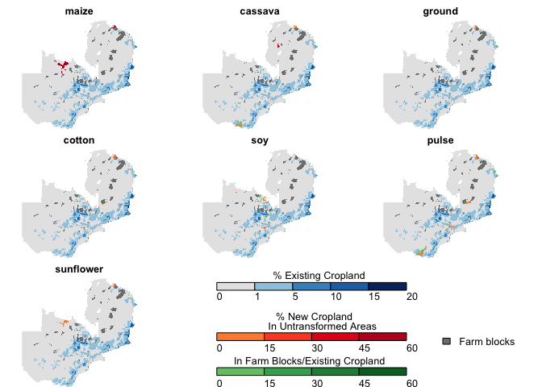

Yield & Carbon & Biodiversity

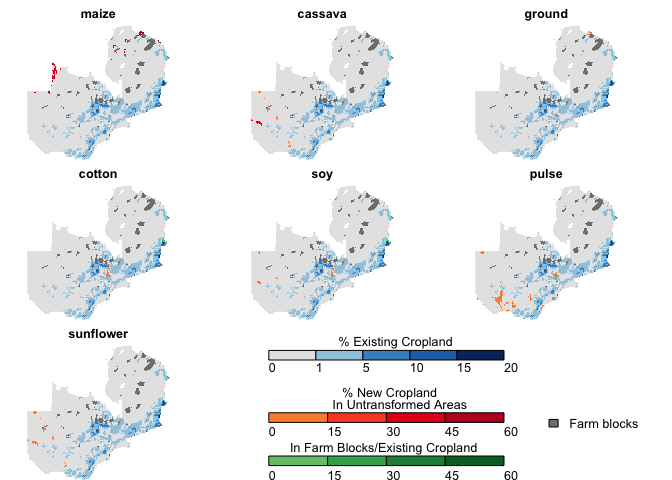

Constraints: Yield & Carbon & Biodiversity & Transport Cost

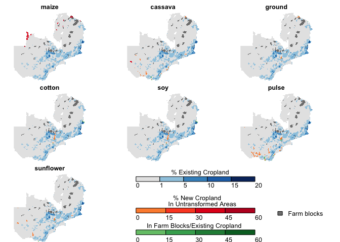

### Cropland Conversion Impacts

- The mode summarizes the country-level impacts along various dimensions, for each crop in terms of:
  - New area converted
  - Mean species richness (in this case, for mammals) per converted grid cell
  - The mean richness per ton of crop yield in converted cells
  - The loss (in ha) of protected areas
  - The tons of carbon lost at conversion per ton of crop yield
  - The total carbon lost (in tonnes)

|  | conv_area | rich_mu | rich/t_yld | pa_loss | tC/t_yld | C_tot |
| --- | --- | --- | --- | --- | --- | --- |
| maize | 292770 | 120.5 | 22.4 | 0 | 26.1 | 3.368e+11 |
| cassava | 84438 | 99.8 | 8.4 | 0 | 7.7 | 6.215e+10 |
| ground | 17253 | 131.0 | 66.7 | 0 | 29.3 | 8.654e+09 |
| cotton | 26860 | 133.3 | 35.9 | 0 | 16.3 | 1.364e+10 |
| soy | 14166 | 118.7 | 49.8 | 0 | 30.8 | 8.786e+09 |
| pulse | 40562 | 104.8 | 115.2 | 0 | 84.1 | 2.627e+10 |
| sunflower | 8601 | 98.6 | 66.5 | 0 | 62.3 | 6.810e+09 |
| sugarcane | 50318 | 116.2 | 1.2 | 0 | 0.7 | 3.015e+10 |
| wheat | 41773 | 103.0 | 22.2 | 0 | 19.4 | 3.106e+10 |

Plotted values of the last 5 scenarios, aggregated across all crops

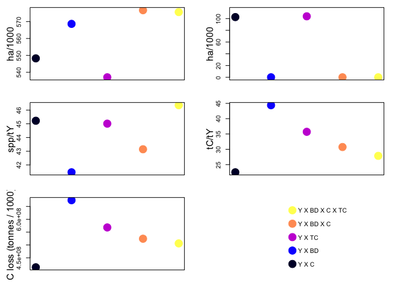

tC/tY versus Yield X Carbon constraints

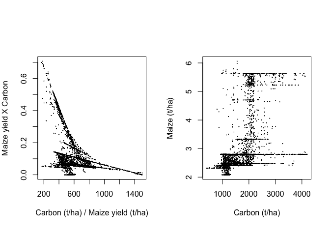